# Vaccine allocation project results

GMB

2022-04-21

# 1 Introduction

This document brings together results from multiple model runs. It is intended to be re-run as the model is updated.

NOTE: The setting for this run is: SLE

**Focus questions:**

- What impact will the existing vaccination plan have on morbidity and mortality?
- What impact can be achieved under different levels of vaccine coverage?
- What are the potential benefits of expanding the immunisation schedule to include children?

**Overarching assumptions**

Unless otherwise specified, key model parameters in this run are:

| Variable | Value | Rational |
| --- | --- | --- |
| Circulating strain | omicron |  |
| Length of model run | 52 |  |
| Current vaccine coverage target | 0.516 | Government target in COVAX documentation May 2021 |
| Proportion of population willing to be vaccinated | 0.88 | Survey estimating vaccine acceptance in January 2021 (Solis et al., 2021) |
| Daily capacity for vaccination (doses) | 55375 | Slightly lower than the pilot vaccination campaign October-November 2021 |
| Anticipated type of future vaccine doses | Johnson & Johnson | The Government of Sierra Leone has demonstrated a strong preference for this vaccine, negotiating with major donors, such as the Government of Italy, to change their donations of double-dose vaccines … |
| Waning of VE against acquisition | TRUE |  |
| Waning of VE against severe disease | TRUE |  |

**Other assumptions/limitations:**

- Linear roll-out of vaccines (Lowy Institute report and trends in the ACT do not support this)
- Vaccine effectiveness estimates last updated on the 14th of April 2022 from WHO live systematic review (https://view-hub.org/covid-19/effectiveness-studies)

**Next steps for noting:**

- update of infection- and vaccine-derived immunity
- sensitivity analysis
  - turning on/off waning of vaccine-derived immunity
  - simulating outbreaks of different strains
  - experimenting with different age-prioritisation strategies
  - other?

# 2 Impact of current program targets

Roll out of current program target (51.6% coverage) during or prior to an outbreak:

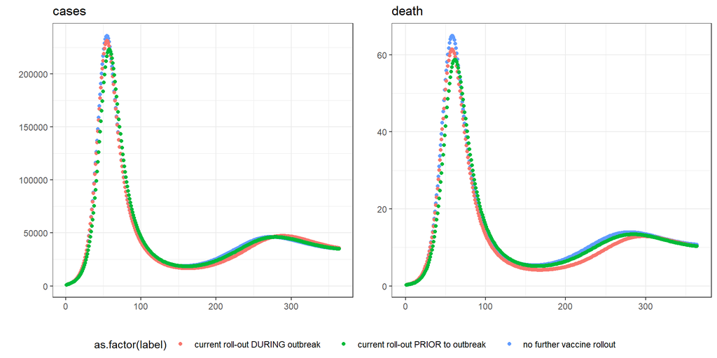

Absolute difference in outcomes

[output not shown]

Relative difference in outcomes

[output not shown]

# 3 Varying levels of coverage

## 3.1 Using current age-specific eligiblity

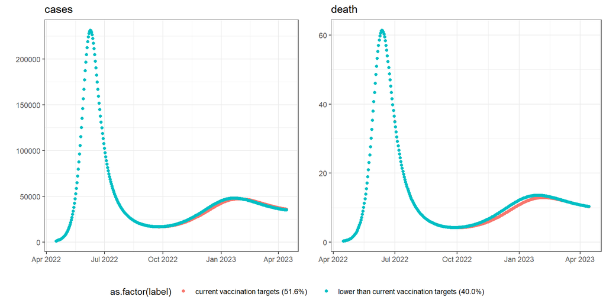

Absolute difference in outcomes

| scenario | death | hosp | severe_disease | YLL | cases |
| --- | --- | --- | --- | --- | --- |
| lower than current vaccination targets (40.0%) | -113 | -5,061 | -1,539 | -1,326 | -130,650 |

Relative difference in outcomes

| scenario | death | hosp | severe_disease | YLL | cases |
| --- | --- | --- | --- | --- | --- |
| lower than current vaccination targets (40.0%) | -2.36 | -1.71 | -2.31 | -2.1 | -0.74 |

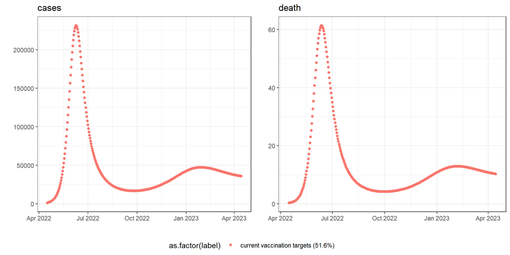

Absolute difference in outcomes

| scenario | death | hosp | severe_disease | YLL | cases |
| --- | --- | --- | --- | --- | --- |

Relative difference in outcomes

| scenario | death | hosp | severe_disease | YLL | cases |
| --- | --- | --- | --- | --- | --- |

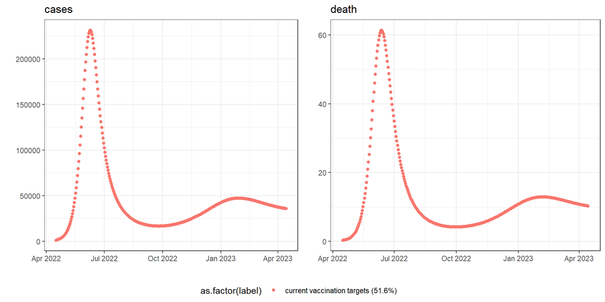

Absolute difference in outcomes

| scenario | death | hosp | severe_disease | YLL | cases |
| --- | --- | --- | --- | --- | --- |

Relative difference in outcomes

| scenario | death | hosp | severe_disease | YLL | cases |
| --- | --- | --- | --- | --- | --- |

# 4 Varying speed of vaccine roll-out

This section models varying speeds of vaccine roll-out *DURING* an outbreak.

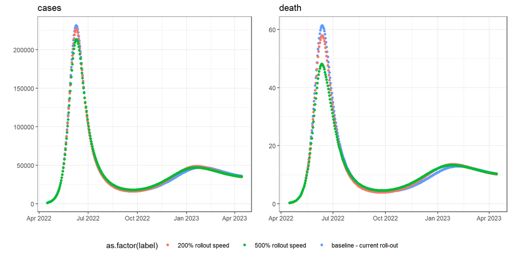

Absolute difference in outcomes

| scenario | death | hosp | severe_disease | YLL | cases |
| --- | --- | --- | --- | --- | --- |
| 200% rollout speed | 87 | 3,022 | 1,062 | 921 | 11,187 |
| 500% rollout speed | 267 | 9,835 | 3,370 | 2,911 | 54,746 |

Relative difference in outcomes

| scenario | death | hosp | severe_disease | YLL | cases |
| --- | --- | --- | --- | --- | --- |
| 200% rollout speed | 1.80 | 1.02 | 1.60 | 1.46 | 0.06 |
| 500% rollout speed | 5.55 | 3.32 | 5.06 | 4.60 | 0.31 |

# 5 Sensitivity analysis (TBC)